# TF-IDF_classification

Evgeniya Khavronina

В этом кодбуке я сделаю классификатор комментариев с помощью метода TF-IDF. Статистическая мера TF-ID используется для оценки важности слова в контексте документа, являющегося частью корпуса.

Размеченный дата-сет с сексистскими высказываниями: https://github.com/gesiscss/theory-driven-sexism-detection

Загружаем библиотеки

```r
library(readr)                 # для чтения csv
library(readxl)                # для чтения xlsx
library(stringr)               # для работы со сторками
library(dplyr)                 # для манипуляций с данными
library(tidytext)              # токинезатор
library(textstem)              # лемматизатор
library(stopwords)             # готовые списки стоп-слов
library(ggplot2)               # визуализация

library(tidyr)                 # функция nest()
library(purrr)                 # функция map()
library(quanteda)              # для работы с dfm

library(caret)                 # обучение моделей
library(glmnet)                # регуляризация моделей
```

### Готовим данные

Датасет с комментариями собран в скрпите preprocessing.Rmd

```r
str(women_en_df)
```

```
spc_tbl_ [74,199 × 4] (S3: spec_tbl_df/tbl_df/tbl/data.frame)
 $ id      : chr [1:74199] "UgyEx6rJ4oDM8emriRB4AaABAg" "UgxsSDLtu-LwC0cumPF4AaABAg" "Ugzaa83eXqdMhY3s42d4AaABAg" "UgyzeDYJscmwHFGKI0Z4AaABAg" ...
 $ text    : chr [1:74199] "We get it! Dataiku does it all" "can i work as a data scientist from home" "too much dataiku spamming" "great tutuorial!!" ...
 $ video_id: num [1:74199] 1 1 1 1 1 1 1 1 1 1 ...
 $ category: chr [1:74199] "DS" "DS" "DS" "DS" ...
 - attr(*, "spec")=
  .. cols(
  ..   id = col_character(),
  ..   text = col_character(),
  ..   video_id = col_double(),
  ..   category = col_character()
  .. )
 - attr(*, "problems")=<externalptr>
```

| id | text | video_id | category |
| --- | --- | --- | --- |
| UgyEx6rJ4oDM8emriRB4AaABAg | We get it! Dataiku does it all | 1 | DS |
| UgxsSDLtu-LwC0cumPF4AaABAg | can i work as a data scientist from home | 1 | DS |
| Ugzaa83eXqdMhY3s42d4AaABAg | too much dataiku spamming | 1 | DS |
| UgyzeDYJscmwHFGKI0Z4AaABAg | great tutuorial!! | 1 | DS |
| UgwkkamH3xTo91XB4PF4AaABAg | Her lip color is so .. delicious. | 1 | DS |
| UgyJIVcf8bj5F3xt1ud4AaABAg | nft shilling, really?. go off queen | 1 | DS |

Чистим текст

```r
# убираем пунктуацию, цифры, табуляцию и переносы строк, лишние пробелы
women_en_df$clean <- gsub("[[:punct:]]", " ", women_en_df$text)
women_en_df$clean <- str_replace_all(women_en_df$clean, "[0-9]+", " ")
women_en_df$clean <- str_replace_all(women_en_df$clean, "[\t\\n\r]+", " ")
women_en_df$clean <- str_squish(women_en_df$clean)

# строки короче 3 символов:
head(women_en_df$clean[nchar(women_en_df$clean)<=2])
```

```
[1] "🙏" "🔥" ""   "🤐" "Hi" "👍"
```

```r
length(women_en_df$clean[nchar(women_en_df$clean)<=2])
```

```
[1] 727
```

```r
# Уберем их
women_en_df <- women_en_df %>%
  filter(nchar(clean) > 2)
```

Токинезируем и лемматизируем слова

```r
# токинезация
women_en_lem <- women_en_df %>%
  group_by(video_id, id) %>%      # группируем по видео и комментарию
  unnest_tokens(word, clean)

# лемматизация
women_en_lem$lemma <- lemmatize_words(women_en_lem$word)

head(women_en_lem)
```

| video_id | id | word | lemma |
| --- | --- | --- | --- |
| 1 | UgyEx6rJ4oDM8emriRB4AaABAg | we | we |
| 1 | UgyEx6rJ4oDM8emriRB4AaABAg | get | get |
| 1 | UgyEx6rJ4oDM8emriRB4AaABAg | it | it |
| 1 | UgyEx6rJ4oDM8emriRB4AaABAg | dataiku | dataiku |
| 1 | UgyEx6rJ4oDM8emriRB4AaABAg | does | do |
| 1 | UgyEx6rJ4oDM8emriRB4AaABAg | it | it |

Размер корпуса в токенах

```r
nrow(women_en_lem)
```

```
[1] 1468752
```

Посмотрим частотности со стоп-словами и без них

```r
sw <- stopwords("en")            # стоп-слова
sw
```

```
  [1] "i"          "me"         "my"         "myself"     "we"         "our"
  [7] "ours"       "ourselves"  "you"        "your"       "yours"      "yourself"
 [13] "yourselves" "he"         "him"        "his"        "himself"    "she"
 [19] "her"        "hers"       "herself"    "it"         "its"        "itself"
 [25] "they"       "them"       "their"      "theirs"     "themselves" "what"
 [31] "which"      "who"        "whom"       "this"       "that"       "these"
 [37] "those"      "am"         "is"         "are"        "was"        "were"
 [43] "be"         "been"       "being"      "have"       "has"        "had"
 [49] "having"     "do"         "does"       "did"        "doing"      "would"
 [55] "should"     "could"      "ought"      "i'm"        "you're"     "he's"
 [61] "she's"      "it's"       "we're"      "they're"    "i've"       "you've"
 [67] "we've"      "they've"    "i'd"        "you'd"      "he'd"       "she'd"
 [73] "we'd"       "they'd"     "i'll"       "you'll"     "he'll"      "she'll"
 [79] "we'll"      "they'll"    "isn't"      "aren't"     "wasn't"     "weren't"
 [85] "hasn't"     "haven't"    "hadn't"     "doesn't"    "don't"      "didn't"
 [91] "won't"      "wouldn't"   "shan't"     "shouldn't"  "can't"      "cannot"
 [97] "couldn't"   "mustn't"    "let's"      "that's"     "who's"      "what's"
[103] "here's"     "there's"    "when's"     "where's"    "why's"      "how's"
[109] "a"          "an"         "the"        "and"        "but"        "if"
[115] "or"         "because"    "as"         "until"      "while"      "of"
[121] "at"         "by"         "for"        "with"       "about"      "against"
[127] "between"    "into"       "through"    "during"     "before"     "after"
[133] "above"      "below"      "to"         "from"       "up"         "down"
[139] "in"         "out"        "on"         "off"        "over"       "under"
[145] "again"      "further"    "then"       "once"       "here"       "there"
[151] "when"       "where"      "why"        "how"        "all"        "any"
[157] "both"       "each"       "few"        "more"       "most"       "other"
[163] "some"       "such"       "no"         "nor"        "not"        "only"
[169] "own"        "same"       "so"         "than"       "too"        "very"
[175] "will"
```

```r
w_freq_word <- women_en_lem %>%
  ungroup() %>%
  filter(nchar(lemma) > 2) %>%   # убираем слова короче 3 символов
  count(lemma, sort=T)           # частотность слов
head(w_freq_word, 20)
```

| lemma | n |
| --- | --- |
| you | 40301 |
| the | 38003 |
| and | 32148 |
| for | 21465 |
| this | 19134 |
| have | 16076 |
| thank | 16062 |
| video | 15071 |
| your | 13601 |
| that | 13066 |

[output cut: 10 more lines]

```r
w_freq_word <- w_freq_word %>%
  filter(!lemma %in% sw)        # убираем стоп-слова
head(w_freq_word, 20)
```

| lemma | n |
| --- | --- |
| thank | 16062 |
| video | 15071 |
| good | 10503 |
| much | 10453 |
| can | 9684 |
| learn | 8527 |
| like | 7873 |
| get | 6990 |
| work | 6935 |
| code | 6366 |

[output cut: 10 more lines]

Чистим окружение

```r
rm(w_freq_word)
rm(sw)
```

### Готовим данные для обучения модели

Читаем размеченные данные

```r
labeled_df <- read_excel(path="C:/Users/79175/Documents/pywd/YT/df_majority.xlsx")
str(labeled_df)
```

```
tibble [3,379 × 10] (S3: tbl_df/tbl/data.frame)
 $ ...1                            : num [1:3379] 0 1 2 3 4 5 6 7 8 9 ...
 $ id                              : num [1:3379] 2 10 12 14 19 23 29 30 45 55 ...
 $ dataset                         : chr [1:3379] "callme" "callme" "benevolent" "scales" ...
 $ text                            : chr [1:3379] "MENTION3111 MENTION3424 ladyboner deserves so much more credit than dudeboner. #bonerdebate #reddetails" "All my sons have grown up with computer games but I'm not interested. I see them as a male thing. MENTION203" "Woman are the future. Rise up, S…
 $ content_categorical             : chr [1:3379] "content_6" "content_1" "content_6" "content_2" ...
 $ phrasing_categorical            : chr [1:3379] "phrasing_3" "phrasing_3" "phrasing_3" "phrasing_3" ...
 $ content_merged_12_56_categorical: chr [1:3379] "content_5" "content_1" "content_5" "content_1" ...
 $ content_binary                  : logi [1:3379] FALSE TRUE FALSE TRUE FALSE FALSE ...
 $ phrasing_binary                 : logi [1:3379] FALSE FALSE FALSE FALSE FALSE FALSE ...
 $ sexist_binary                   : logi [1:3379] FALSE TRUE FALSE TRUE FALSE FALSE ...
```

```r
labeled_df %>%
  select(text, content_binary, phrasing_binary, sexist_binary) %>%
  head()
```

| text | content_binary | phrasing_binary | sexist_binary |
| --- | --- | --- | --- |
| MENTION3111 MENTION3424 ladyboner deserves so much more credit than dudeboner. #bonerdebate #reddetails | FALSE | FALSE | FALSE |
| All my sons have grown up with computer games but I'm not interested. I see them as a male thing. MENTION203 | TRUE | FALSE | TRUE |
| Woman are the future. Rise up, Stand up, Shine on. \n#adaywithoutwomen\n#internationalwomensday… https://t.co/Nc7PsmLiN2 | FALSE | FALSE | FALSE |
| Women have more intuition than men. | TRUE | FALSE | TRUE |
| Lo cewek ya? "MENTION4162: I have zero tolerance for cowok riwil. Riwil is girls' nature." | FALSE | FALSE | FALSE |
| MENTION996 you don't understand my intent | FALSE | FALSE | FALSE |

Посмотрим соотношение сексистских и несексистских высказываний в размеченных датасетах

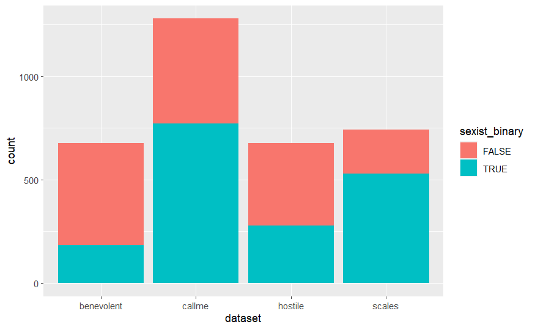

```r
ggplot(labeled_df, aes(dataset, fill=sexist_binary)) +
  geom_bar()
```

Content указывает на содержание высказывания, phrasing указывает на формулировку высказывания.

Пример сексистского высказывания по содержанию:

```r
sample(labeled_df$text[labeled_df$content_binary == T
                       & labeled_df$phrasing_binary == F], 1)
```

```
[1] "MENTION1314 i understand especially when it comes to self defense. Im not sexist but there's some things that were meant just for men"
```

Пример сексистского (только) по формулировке высказывания:

```r
sample(labeled_df$text[labeled_df$content_binary == F
                       & labeled_df$phrasing_binary == T], 1)
```

```
[1] "I'm gonna gouge my eyes out if this bitch doesn't get off #mkr #catandandre"
```

```r
labeled_df %>%
  group_by(content_binary, phrasing_binary) %>%
  count()
```

| content_binary | phrasing_binary | n |
| --- | --- | --- |
| FALSE | FALSE | 1617 |
| FALSE | TRUE | 8 |
| TRUE | FALSE | 1633 |
| TRUE | TRUE | 121 |

Мета-данные с id высказывания (твита) и лейблом

```r
labeled_df <- labeled_df %>%
  mutate(sent_id = row_number())  # добавляем номер твита

labeled_meta <- labeled_df %>%
  select(sent_id, sexist_binary)

# преобразуем лейбл в фактор
labeled_meta$sexist_binary <- as.factor(labeled_meta$sexist_binary)
levels(labeled_meta$sexist_binary) <- c("non-sexist", "sexist")
levels(labeled_meta$sexist_binary)
```

```
[1] "non-sexist" "sexist"
```

Трансформируем данные в длинный формат и чистим. Уберем слово “mention” т. к. им заменялись все упоминания в твитах

```r
# убираем лишнее
labeled_df$clean <- gsub("[[:punct:]]", " ", labeled_df$text)
labeled_df$clean <- str_replace_all(labeled_df$clean, "[0-9]+", " ")
labeled_df$clean <- str_replace_all(labeled_df$clean, "[\t\\n\r]+", " ")
labeled_df$clean <- str_squish(labeled_df$clean)

labeled_long <- labeled_df %>%
  group_by(sent_id, sexist_binary) %>%   # группируем по id и лейблу
  unnest_tokens(word, clean) %>%         # токинезируем
  filter(! word == "mention")            # уберем слово "mention"

labeled_long$lemma <- lemmatize_words(labeled_long$word) # лемматизируем

labeled_long <- labeled_long %>%
  select(-word)                          # убираем лишнюю колонку


# собираем твиты обратно из слов в списки
labeled_nested <- labeled_long %>%
  group_by(sent_id, sexist_binary) %>%   # группируем
  tidyr::nest(lemma) %>%                 # собираем в списки
  mutate(text = map(data, unlist),       # из списков делаем обратно тексты
         text = map_chr(text, paste, collapse = " "))
labeled_nested$sexist_binary <- as.factor(labeled_nested$sexist_binary)
levels(labeled_nested$sexist_binary) <- c("non-sexist", "sexist")

head(labeled_nested)
```

| sent_id | sexist_binary | data | text |
| --- | --- | --- | --- |
| 1 | non-sexist |  | ladyboner deserve so much much credit than dudeboner bonerdebate reddetails |
| 2 | sexist |  | all my son have grow up with computer game but i be not interest i see them as a male thing |
| 3 | non-sexist |  | woman be the future rise up stand up shine on adaywithoutwomen internationalwomensday https t co nc psmlin |
| 4 | sexist |  | woman have much intuition than man |
| 5 | non-sexist |  | lo cewek you i have zero tolerance for cowok riwil riwil be girl nature |
| 6 | non-sexist |  | you don t understand my intent |

Создаем матрицу термов-документов

```r
labeled_dtm <- labeled_long %>%
  ungroup() %>%
  count(sent_id, lemma) %>%           # считаем частотности по каждому твиту
  bind_tf_idf(lemma, sent_id, n) %>%  # объединяем term frequency и inverse document frequency
  cast_dfm(sent_id, lemma, tf_idf)    # создаем матрицу

labeled_dtm
```

```
Document-feature matrix of: 3,379 documents, 5,719 features (99.74% sparse) and 0 docvars.
    features
docs bonerdebate    credit   deserve dudeboner ladyboner      much reddetails        so
   1   0.8125335 0.6515897 0.5352746 0.8125335 0.8125335 0.4517734  0.8125335 0.3242533
   2   0         0         0         0         0         0          0         0
   3   0         0         0         0         0         0          0         0
   4   0         0         0         0         0         0.3764778  0         0
   5   0         0         0         0         0         0          0         0
   6   0         0         0         0         0         0          0         0
    features
docs      than          a
   1 0.2458908 0
   2 0         0.03607745
   3 0         0
   4 0.4098181 0
   5 0         0
   6 0         0
[ reached max_ndoc ... 3,373 more documents, reached max_nfeat ... 5,709 more features ]
```

Можно еще немного почистить матрицу, но это практически не влияет на результат

```r
labeled_clean <- labeled_dtm %>%
    dfm_wordstem(language = "en") %>%
    dfm_trim(min_docfreq=0.10)
labeled_clean
```

```
Document-feature matrix of: 3,379 documents, 1,832 features (99.27% sparse) and 0 docvars.
    features
docs    credit    deserv      much        so      than          a       all        as
   1 0.6515897 0.5352746 0.4517734 0.3242533 0.2458908 0          0         0
   2 0         0         0         0         0         0.03607745 0.1464514 0.1145249
   3 0         0         0         0         0         0          0         0
   4 0         0         0.3764778 0         0.4098181 0          0         0
   5 0         0         0         0         0         0          0         0
   6 0         0         0         0         0         0          0         0
    features
docs         be       but
   1 0          0
   2 0.02933332 0.1112083
   3 0.03623528 0
   4 0          0
   5 0.04399999 0
   6 0          0
[ reached max_ndoc ... 3,373 more documents, reached max_nfeat ... 1,822 more features ]
```

Тренировочная и тестовая выборка (10%)

```r
set.seed(9)

# делим датасет (90:10)
split <- createDataPartition(y=labeled_meta$sexist_binary, p = 0.9, list = FALSE)
# обучающая выборка
train.data <- labeled_dtm %>%
  dfm_subset(rownames(labeled_dtm) %in% labeled_meta$sent_id[split])
# тестовая выборка
test.data <- labeled_dtm %>%
  dfm_subset(!rownames(labeled_dtm) %in% labeled_meta$sent_id[split])

response <- as.factor(labeled_nested$sexist_binary)
trainY <- response[split]
testY <- response[-split]
```

Обучаем модели

```r
#cv.ridge <- cv.glmnet(
#  x=train.data, y=trainY, alpha=0, family="binomial", type.measure="auc", nfolds = 5, standardize=FALSE)
```

```r
cv.lasso <- cv.glmnet(
  x=train.data, y=trainY, alpha=1, family="binomial", type.measure="auc", nfolds = 5, standardize=FALSE)
```

```r
cv.elasticnet <- cv.glmnet(
  x=train.data, y=trainY, family="binomial", type.measure="auc", nfolds = 5, standardize=FALSE)
```

Предсказываем лейбл на тестовой выборке

```r
predicted.lasso <- as.factor(predict(cv.lasso, test.data, type="class"))
#predicted.ridge <- as.factor(predict(cv.ridge, test.data, type="class"))
predicted.elasticnet <- as.factor(predict(cv.elasticnet, test.data, type="class"))
```

Следующая модель без стоп-слов предсказывает примерно одинаково с labeled_dtm и с labeled_clean. Лучше всего предсказывает, если не убирать стоп-слова:

```r
cm.lasso <- confusionMatrix(
  data = predicted.lasso, reference = testY, positive="sexist", mode = "prec_recall")
cm.lasso
```

```
Confusion Matrix and Statistics

            Reference
Prediction   non-sexist sexist
  non-sexist        105     28
  sexist             56    148

               Accuracy : 0.7507
                 95% CI : (0.701, 0.796)
    No Information Rate : 0.5223
    P-Value [Acc > NIR] : < 2e-16

                  Kappa : 0.4968

 Mcnemar's Test P-Value : 0.00322

              Precision : 0.7255
                 Recall : 0.8409
                     F1 : 0.7789
             Prevalence : 0.5223
         Detection Rate : 0.4392
   Detection Prevalence : 0.6053
      Balanced Accuracy : 0.7465

       'Positive' Class : sexist
```

```r
#cm.ridge <- confusionMatrix(
#  data = predicted.ridge, reference = testY, positive="sexist", mode = "prec_recall")
#cm.ridge
```

Следующая модель без стоп-слов предсказывает немного лучше с labeled_dtm, чем с labeled_clean. Лучше всего работает со стоп-словами.

```r
cm.elasticnet <- confusionMatrix(
  data = predicted.elasticnet, reference = testY, positive="sexist", mode = "prec_recall")
cm.elasticnet
```

```
Confusion Matrix and Statistics

            Reference
Prediction   non-sexist sexist
  non-sexist        105     28
  sexist             56    148

               Accuracy : 0.7507
                 95% CI : (0.701, 0.796)
    No Information Rate : 0.5223
    P-Value [Acc > NIR] : < 2e-16

                  Kappa : 0.4968

 Mcnemar's Test P-Value : 0.00322

              Precision : 0.7255
                 Recall : 0.8409
                     F1 : 0.7789
             Prevalence : 0.5223
         Detection Rate : 0.4392
   Detection Prevalence : 0.6053
      Balanced Accuracy : 0.7465

       'Positive' Class : sexist
```

Анализ переменных

```r
coef(cv.lasso, cv.lasso$lambda.min) %>%
  as.matrix %>% as.data.frame %>%
  tibble::rownames_to_column() %>%
  arrange(-abs(`s1`)) %>%
  head(100)
```

|  | rowname | s1 |
| --- | --- | --- |
| 1 | woman | 12.796168 |
| 2 | womensday | -12.646960 |
| 3 | man | 8.599960 |
| 4 | mkr | -8.173817 |
| 5 | love | -6.922081 |
| 6 | female | 6.916243 |
| 7 | girl | 6.813007 |
| 8 | co | -5.735861 |
| 9 | lucky | -5.414434 |
| 10 | drive | 5.359275 |

[output cut: 90 more lines]

```r
NA
```

```r
#coef(cv.ridge, cv.ridge$lambda.min) %>%
#  as.matrix %>% as.data.frame %>%
#  tibble::rownames_to_column() %>%
#  arrange(-abs(`s1`)) %>%
#  head(100)
```

```r
coef(cv.elasticnet, cv.elasticnet$lambda.min) %>%
  as.matrix %>% as.data.frame %>%
  tibble::rownames_to_column() %>%
  arrange(-abs(`s1`)) %>%
  head(100)
```

|  | rowname | s1 |
| --- | --- | --- |
| 1 | woman | 13.157543 |
| 2 | womensday | -12.904795 |
| 3 | man | 8.744362 |
| 4 | mkr | -8.465821 |
| 5 | female | 7.109196 |
| 6 | love | -7.018478 |
| 7 | girl | 7.006014 |
| 8 | lucky | -5.757215 |
| 9 | co | -5.749855 |
| 10 | drive | 5.629704 |

[output cut: 90 more lines]

### Используем модель на комментариях

Создадим список слов, которые есть в тренировочном датасете

```r
vocab <- unique(labeled_long$lemma)
length(vocab)  # размер словаря
```

```
[1] 5719
```

Отметим комментарии, которые не содержат ни одного слова из словаря тренировочного датасета. При классификации они могут быть помечены как сексистские.

| id | text | video_id | category | clean | result |
| --- | --- | --- | --- | --- | --- |
| Ugx0FdCWlfGGY_LvhQp4AaABAg | 7:17 XDDDDDDDDDDDDDDDDDD | 1 | DS | XDDDDDDDDDDDDDDDDDD | unidentified |
| UgyuZVyyHpYcuuV--o94AaABAg | Ммм, какая сладкая азиатка | 1 | DS | Ммм какая сладкая азиатка | unidentified |
| UgwNAngMyqiH1_99kzt4AaABAg | Thankyouuu | 1 | DS | Thankyouuu | unidentified |
| Ugx7ZA0SnjCOUKmLGLF4AaABAg | 😇😅😂 | 2 | DS | 😇😅😂 | unidentified |
| UgyzG-7Di7Had1dp-4h4AaABAg | 😍😍😍😍😍😍😍😍😍😍😍😍😍😍😍😍😍😍😍😍😍😍😍😍😍 | 2 | DS | 😍😍😍😍😍😍😍😍😍😍😍😍😍😍😍😍😍😍😍😍😍😍😍😍😍 | unidentified |
| Ugw1Mhe3x1yrRmESyfR4AaABAg | QNA | 2 | DS | QNA | unidentified |

```r
women_nested <- women_long %>%
  group_by(id) %>%
  tidyr::nest(lemma) %>%
  mutate(text = map(data, unlist),
         text = map_chr(text, paste, collapse = " "))
```

Создаем матрицу термов-документов

```r
women_dtm <- women_long %>%
  ungroup() %>%
  count(id, lemma) %>%
  bind_tf_idf(lemma, id, n) %>%
  cast_dfm(id, lemma, tf_idf)

women_dtm
```

```
Document-feature matrix of: 73,283 documents, 34,121 features (99.95% sparse) and 0 docvars.
                      features
docs                        dan         it     make    simple      thank      very        you
  Ugg_yP7W41PJjXgCoAEC 1.245311 0.24646201 0.387466 0.6566837 0.22510489 0.3767764 0.14219266
  Ugg4KZbnuoQLZ3gCoAEC 0        0          0        0         0          0         0
  Ugg5kpug-UGafngCoAEC 0        0.08626170 0        0         0          0         0
  Ugg6h-ZIbWspEHgCoAEC 0        0.04423677 0        0         0.04040344 0         0
  UggEWeq8ObDTFHgCoAEC 0        0          0        0         0.06565559 0         0.04147286
  UggiImmgxj2bP3gCoAEC 0        0          0        0         0          0         0.33178286
                      features
docs                         get          i       now
  Ugg_yP7W41PJjXgCoAEC 0         0          0
  Ugg4KZbnuoQLZ3gCoAEC 0.4207457 0.16212531 0.5489495
  Ugg5kpug-UGafngCoAEC 0.1262237 0          0
  Ugg6h-ZIbWspEHgCoAEC 0         0.04988471 0
  UggEWeq8ObDTFHgCoAEC 0         0          0
  UggiImmgxj2bP3gCoAEC 0         0          0
[ reached max_ndoc ... 73,277 more documents, reached max_nfeat ... 34,111 more features ]
```

Сделаем матрицу совместимой с моделью: подгоняем размер матрицы реального датасета и тренировочного. Лишние слова убираются, на места недостающих добавляются нули.

```r
women_dtm <- dfm_match(women_dtm, featnames(labeled_dtm))
women_dtm
```

```
Document-feature matrix of: 73,283 documents, 5,719 features (99.76% sparse) and 0 docvars.
                      features
docs                   bonerdebate credit deserve dudeboner ladyboner       much reddetails
  Ugg_yP7W41PJjXgCoAEC           0      0       0         0         0 0                   0
  Ugg4KZbnuoQLZ3gCoAEC           0      0       0         0         0 0                   0
  Ugg5kpug-UGafngCoAEC           0      0       0         0         0 0                   0
  Ugg6h-ZIbWspEHgCoAEC           0      0       0         0         0 0                   0
  UggEWeq8ObDTFHgCoAEC           0      0       0         0         0 0.08877754          0
  UggiImmgxj2bP3gCoAEC           0      0       0         0         0 0                   0
                      features
docs                          so than          a
  Ugg_yP7W41PJjXgCoAEC 0            0 0
  Ugg4KZbnuoQLZ3gCoAEC 0            0 0
  Ugg5kpug-UGafngCoAEC 0.2058738    0 0
  Ugg6h-ZIbWspEHgCoAEC 0            0 0.09184008
  UggEWeq8ObDTFHgCoAEC 0            0 0.04974671
  UggiImmgxj2bP3gCoAEC 0            0 0
[ reached max_ndoc ... 73,277 more documents, reached max_nfeat ... 5,709 more features ]
```

Используем классификатор elasticnet

| id | result | text | video_id |
| --- | --- | --- | --- |
| UgyEx6rJ4oDM8emriRB4AaABAg | non-sexist | We get it! Dataiku does it all | 1 |
| UgxsSDLtu-LwC0cumPF4AaABAg | non-sexist | can i work as a data scientist from home | 1 |
| Ugzaa83eXqdMhY3s42d4AaABAg | non-sexist | too much dataiku spamming | 1 |
| UgyzeDYJscmwHFGKI0Z4AaABAg | sexist | great tutuorial!! | 1 |
| UgwkkamH3xTo91XB4PF4AaABAg | non-sexist | Her lip color is so .. delicious. | 1 |
| UgyJIVcf8bj5F3xt1ud4AaABAg | non-sexist | nft shilling, really?. go off queen | 1 |

| id | result | text | video_id |
| --- | --- | --- | --- |
| UgyzeDYJscmwHFGKI0Z4AaABAg | sexist | great tutuorial!! | 1 |
| UgzysMmt7S5HGpLIqlF4AaABAg | sexist | Money is supposed to be flowing in? I guess my bank statement is broken because I only see money flowing out. 😔 | 1 |
| Ugwd6swpAe6VN8Q7U0Z4AaABAg | sexist | I think I'm in love with this girl | 1 |
| Ugw8NSiyljBgrFX5kGt4AaABAg | sexist | Amazing - thank you! | 1 |
| Ugx0FdCWlfGGY_LvhQp4AaABAg | sexist | 7:17 XDDDDDDDDDDDDDDDDDD | 1 |
| UgxtsHtLWtuf_G2HUyx4AaABAg | sexist | League of legends' community is one of the most toxic there is. The game is notorious for it. But the project sounds fun. Thank you for these suggestions. Eye openers, really. | 1 |
| UgzD2YSrJY5g0GMgeil4AaABAg | sexist | Thank you! Looking forward to more insightful videos. | 1 |
| Ugz6hpug3NohsC9LNG54AaABAg | sexist | Youtube sentiment analysis. Thank you | 1 |
| UgyOZDm-SvDs_HPs9P94AaABAg | sexist | Niiiice video and nice chanel. Like and suscribed fron Argentina. Please, keep it up | 1 |
| UgzsgDN_AI-NxaYYFfJ4AaABAg | sexist | I like the NFT idea! But by looking at the dataset and the Feature importance article, I don't understand how to implement that, can someone give me a hint? | 1 |

[output cut: 990 more lines]

| result | n |
| --- | --- |
| non-sexist | 67618 |
| sexist | 5665 |

Используем классификатор lasso

| id | result | text | video_id |
| --- | --- | --- | --- |
| UgyEx6rJ4oDM8emriRB4AaABAg | non-sexist | We get it! Dataiku does it all | 1 |
| UgxsSDLtu-LwC0cumPF4AaABAg | non-sexist | can i work as a data scientist from home | 1 |
| Ugzaa83eXqdMhY3s42d4AaABAg | non-sexist | too much dataiku spamming | 1 |
| UgyzeDYJscmwHFGKI0Z4AaABAg | sexist | great tutuorial!! | 1 |
| UgwkkamH3xTo91XB4PF4AaABAg | non-sexist | Her lip color is so .. delicious. | 1 |
| UgyJIVcf8bj5F3xt1ud4AaABAg | non-sexist | nft shilling, really?. go off queen | 1 |

| id | result | text | video_id |
| --- | --- | --- | --- |
| UgyzeDYJscmwHFGKI0Z4AaABAg | sexist | great tutuorial!! | 1 |
| UgzysMmt7S5HGpLIqlF4AaABAg | sexist | Money is supposed to be flowing in? I guess my bank statement is broken because I only see money flowing out. 😔 | 1 |
| Ugwd6swpAe6VN8Q7U0Z4AaABAg | sexist | I think I'm in love with this girl | 1 |
| Ugw8NSiyljBgrFX5kGt4AaABAg | sexist | Amazing - thank you! | 1 |
| Ugx0FdCWlfGGY_LvhQp4AaABAg | sexist | 7:17 XDDDDDDDDDDDDDDDDDD | 1 |
| UgxtsHtLWtuf_G2HUyx4AaABAg | sexist | League of legends' community is one of the most toxic there is. The game is notorious for it. But the project sounds fun. Thank you for these suggestions. Eye openers, really. | 1 |
| UgzD2YSrJY5g0GMgeil4AaABAg | sexist | Thank you! Looking forward to more insightful videos. | 1 |
| Ugz6hpug3NohsC9LNG54AaABAg | sexist | Youtube sentiment analysis. Thank you | 1 |
| UgyOZDm-SvDs_HPs9P94AaABAg | sexist | Niiiice video and nice chanel. Like and suscribed fron Argentina. Please, keep it up | 1 |
| UgzsgDN_AI-NxaYYFfJ4AaABAg | sexist | I like the NFT idea! But by looking at the dataset and the Feature importance article, I don't understand how to implement that, can someone give me a hint? | 1 |

[output cut: 990 more lines]

| result | n |
| --- | --- |
| non-sexist | 67618 |
| sexist | 5665 |

Пока что результаты так себе. Однако я уже исправила ошибку, которая, как оказалось, полностью портила модель.